# notebook

Project: Detecting Cyber Security Threats using Deep Learning using PyTorch

Cyber threats are a growing concern for organizations worldwide. These threats take many forms, including malware, phishing, and denial-of-service (DOS) attacks, compromising sensitive information and disrupting operations. The increasing sophistication and frequency of these attacks make it imperative for organizations to adopt advanced security measures. Traditional threat detection methods often fall short due to their inability to adapt to new and evolving threats. This is where deep learning models come into play.

Deep learning models can analyze vast amounts of data and identify patterns that may not be immediately obvious to human analysts. By leveraging these models, organizations can proactively detect and mitigate cyber threats, safeguarding their sensitive information and ensuring operational continuity.

As a cybersecurity analyst, in this project I identify and mitigate these threats. In this project, I will design and implement a deep learning model to detect cyber threats. The BETH dataset simulates real-world logs, providing a rich source of information for training and testing your model. The data has already undergone preprocessing, and has a target label, `sus_label`, indicating whether an event is malicious (1) or benign (0).

By successfully developing this model, I will contribute to enhancing cybersecurity measures and protecting organizations from potentially devastating cyber attacks.

### The Data

[output not shown]

More information on the dataset: BETH dataset

```python
# Import required libraries
import pandas as pd
from sklearn.preprocessing import StandardScaler
!pip install torch torchvision torchaudio --index-url https://download.pytorch.org/whl/cpu
!pip install torchmetrics

import torch
import torch.nn as nn
import torch.nn.functional as functional
from torch.utils.data import DataLoader, TensorDataset
import torch.optim as optim
from torchmetrics import Accuracy
# from sklearn.metrics import accuracy_score  # uncomment to use sklearn
```

```python
# Load preprocessed data
train_df = pd.read_csv('labelled_train.csv')
test_df = pd.read_csv('labelled_test.csv')
val_df = pd.read_csv('labelled_validation.csv')

# View the first 5 rows of training set
train_df.head()
```

|  | processId | threadId | parentProcessId | userId | mountNamespace | argsNum | returnValue | sus_label |
| --- | --- | --- | --- | --- | --- | --- | --- | --- |
| 0 | 381 | 7337 | 1 | 100 | 4026532231 | 5 | 0 | 1 |
| 1 | 381 | 7337 | 1 | 100 | 4026532231 | 1 | 0 | 1 |
| 2 | 381 | 7337 | 1 | 100 | 4026532231 | 0 | 0 | 1 |
| 3 | 7347 | 7347 | 7341 | 0 | 4026531840 | 2 | -2 | 1 |
| 4 | 7347 | 7347 | 7341 | 0 | 4026531840 | 4 | 0 | 1 |

```python
test_df.head()
```

|  | processId | threadId | parentProcessId | userId | mountNamespace | argsNum | returnValue | sus_label |
| --- | --- | --- | --- | --- | --- | --- | --- | --- |
| 0 | 382 | 382 | 1 | 101 | 4026532232 | 3 | 15 | 0 |
| 1 | 379 | 379 | 1 | 100 | 4026532231 | 3 | 15 | 0 |
| 2 | 1 | 1 | 0 | 0 | 4026531840 | 4 | 0 | 0 |
| 3 | 1 | 1 | 0 | 0 | 4026531840 | 4 | 17 | 0 |
| 4 | 1 | 1 | 0 | 0 | 4026531840 | 2 | 0 | 0 |

```python
val_df.head()
```

|  | processId | threadId | parentProcessId | userId | mountNamespace | argsNum | returnValue | sus_label |
| --- | --- | --- | --- | --- | --- | --- | --- | --- |
| 0 | 381 | 381 | 1 | 101 | 4026532232 | 3 | 15 | 0 |
| 1 | 378 | 378 | 1 | 100 | 4026532231 | 3 | 15 | 0 |
| 2 | 1 | 1 | 0 | 0 | 4026531840 | 4 | 0 | 0 |
| 3 | 1 | 1 | 0 | 0 | 4026531840 | 4 | 12 | 0 |
| 4 | 1 | 1 | 0 | 0 | 4026531840 | 2 | 0 | 0 |

```python
# Separate features and labels for training, testing, and validation sets
X_train = train_df.drop('sus_label', axis=1).values
y_train = train_df['sus_label'].values
X_test = test_df.drop('sus_label', axis=1).values
y_test = test_df['sus_label'].values
X_val = val_df.drop('sus_label', axis=1).values
y_val = val_df['sus_label'].values

# Initialize the StandardScaler
scaler = StandardScaler()

# Fit the scaler on the training data and transform the training data
X_train = scaler.fit_transform(X_train)

# Transform the test and validation data using the fitted scaler
X_test = scaler.transform(X_test)
X_val = scaler.transform(X_val)

# Convert the numpy arrays to PyTorch tensors
X_train_tensor = torch.tensor(X_train, dtype=torch.float32)
y_train_tensor = torch.tensor(y_train, dtype=torch.float32).view(-1, 1)
X_test_tensor = torch.tensor(X_test, dtype=torch.float32)
y_test_tensor = torch.tensor(y_test, dtype=torch.float32).view(-1, 1)
X_val_tensor = torch.tensor(X_val, dtype=torch.float32)
y_val_tensor = torch.tensor(y_val, dtype=torch.float32).view(-1, 1)

# Define the model using nn.Sequential
model = nn.Sequential(
    nn.Linear(X_train.shape[1], 128),  # First fully connected layer
    nn.ReLU(),  # ReLU activation
    nn.Linear(128, 64),  # Second fully connected layer
    nn.ReLU(),  # ReLU activation
    nn.Linear(64, 1),  # Third fully connected layer
    nn.Sigmoid()  # Sigmoid activation for binary classification
)

# Initialize the loss function and optimizer
#criterion = nn.CrossEntropyLoss()

#optimizer = optim.SGD(model.parameters(), lr=1e-3, weight_decay=1e-4)

# Use weighted BCE for imbalance:
#num_pos = (y_train_tensor == 1).sum()
#num_neg = (y_train_tensor == 0).sum()
#pos_weight = num_neg / num_pos
#criterion = nn.BCEWithLogitsLoss(pos_weight=pos_weight)

"""
try BCELoss() - Binary Cross Entropy Loss for binary classification, meaning the model only have 2 classes. This will provide accurate and higher probability.

try optimizer = optim.Adam(model.parameters(), lr=0.001)  # Adam optimizer with learning rate 0.001

Adam computes individual adaptive learning rates for different parameters from
estimates of first and second moments of the gradients. This helps in faster convergence and better handling of sparse gradients. Adam is generally better than SGD for most problems as it adapts the learning rate for each parameter, which can lead to better performance and faster training.
"""
# Weighted BCE to handle class imbalance
num_pos = (y_train_tensor == 1).sum()
num_neg = (y_train_tensor == 0).sum()
pos_weight = num_neg / num_pos
criterion = nn.BCEWithLogitsLoss(pos_weight=pos_weight)
optimizer = optim.Adam(model.parameters(), lr=0.001)

# Training loop
num_epoch = 10
for epoch in range(num_epoch):
    model.train()  # Set the model to training mode
    optimizer.zero_grad()  # Clear the gradients
    outputs = model(X_train_tensor)  # Forward pass: compute the model output
    loss = criterion(outputs, y_train_tensor)  # Compute the loss
    loss.backward()  # Backward pass: compute the gradients
    optimizer.step()  # Update the model parameters

# Model Evaluation
model.eval()  # Set the model to evaluation mode
with torch.no_grad():  # Disable gradient calculation for efficiency
    y_predict_train = model(X_train_tensor).round()  # Predict on training data and round the outputs
    y_predict_test = model(X_test_tensor).round()  # Predict on test data and round the outputs
    y_predict_val = model(X_val_tensor).round()  # Predict on validation data and round the outputs

# Calculate accuracy using torchmetrics
accuracy = Accuracy(task="binary")

train_accuracy = accuracy(y_predict_train, y_train_tensor)
test_accuracy = accuracy(y_predict_test, y_test_tensor)
val_accuracy = accuracy(y_predict_val, y_val_tensor)

# convert to int or float
train_accuracy = train_accuracy.item()
test_accuracy = test_accuracy.item()
val_accuracy = val_accuracy.item()

print("Training accuracy: {0}".format(train_accuracy))
print("Validation accuracy: {0}".format(val_accuracy))
print("Testing accuracy: {0}".format(test_accuracy))

# Calculate the accuracy using sklearn
# train_accuracy = accuracy_score(y_train_tensor, y_predict_train)
# val_accuracy = accuracy_score(y_val_tensor, y_predict_val)
# test_accuracy = accuracy_score(y_test_tensor, y_predict_test)
```

```
Training accuracy: 0.9902482628822327
Validation accuracy: 0.9969624280929565
Testing accuracy: 0.945276141166687
```

- Why I did this and what I saw - Weighted BCE to handle class imbalance

Initially, the model achieved very high training and validation accuracy, but test accuracy was extremely low (~0.09). This indicated that the model was overfitting to the training/validation data and failing to generalize to unseen data.

The main issue was class imbalance: malicious events (label=1) were much fewer than benign events (label=0), so the model mostly predicted the majority class.

- Training accuracy: ~0.99
- Validation accuracy: ~0.997
- Testing accuracy: ~0.945

This shows that the model now generalizes well to unseen data and can effectively detect malicious events.

```python
# Precision, Recall and F1 score
from torchmetrics import Precision, Recall, F1Score
precision = Precision(task="binary")(y_predict_test, y_test_tensor).item()
recall = Recall(task="binary")(y_predict_test, y_test_tensor).item()
f1 = F1Score(task="binary")(y_predict_test, y_test_tensor).item()
print("Precision:", precision, "Recall:", recall, "F1:", f1)
```

```
Precision: 0.9988914728164673 Recall: 0.9407321810722351 F1: 0.9689399003982544
```

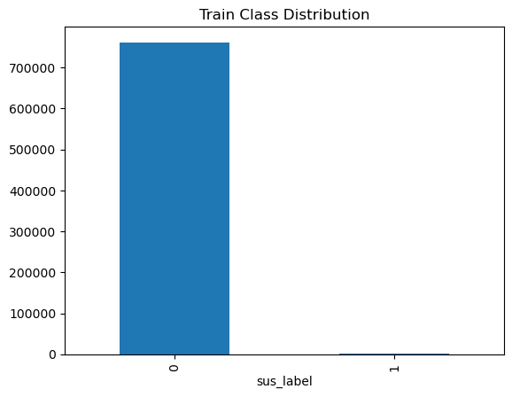

```python
# Class Balance Check
import matplotlib.pyplot as plt
from sklearn.metrics import confusion_matrix, ConfusionMatrixDisplay
import seaborn as sns

# 1️⃣ Class distribution
train_df['sus_label'].value_counts().plot(kind='bar', title='Train Class Distribution')
plt.show()
```

- Precision ~0.999 → The model is extremely accurate when it predicts an event as malicious; almost no false positives.
- Recall ~0.941 → The model correctly identifies ~94% of all actual malicious events; very few are missed.
- F1 ~0.969 → High balance between precision and recall → model is strong at detecting malicious events. Class Imbalance Graph → Confirms that the dataset is dominated by benign events (label 0). The weighted loss helped the model focus on the minority class.

```
Confusion Matrix:
 tensor([[ 17329,    179],
        [ 10162, 161297]])
```

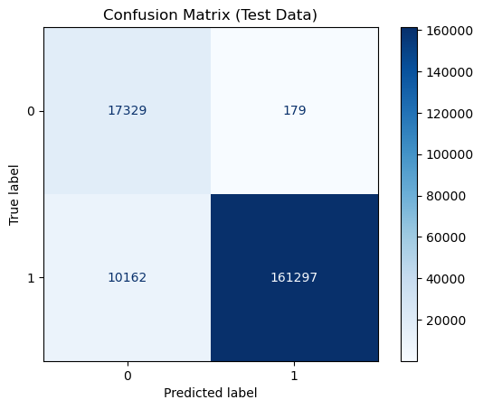

```python
# Confusion Matrix
from torchmetrics import ConfusionMatrix
confmat = ConfusionMatrix(task="binary")
cm = confmat(y_predict_test, y_test_tensor)
print("Confusion Matrix:\n", cm)

# 2️⃣ Confusion Matrix plot
y_pred_np = y_predict_test.numpy()
y_true_np = y_test_tensor.numpy()
cm = confusion_matrix(y_true_np, y_pred_np)
disp = ConfusionMatrixDisplay(confusion_matrix=cm)
disp.plot(cmap='Blues', values_format='d')
plt.title("Confusion Matrix (Test Data)")
plt.show()
```

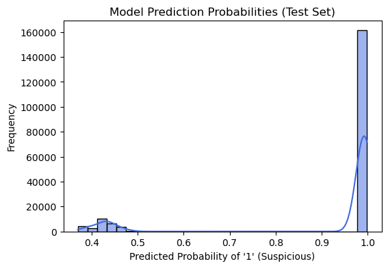

```python
# 3️⃣ Model Prediction Probabilities
with torch.no_grad():
    y_prob_test = model(X_test_tensor).numpy().flatten()

plt.figure(figsize=(6,4))
sns.histplot(y_prob_test, bins=30, kde=True, color='royalblue')
plt.title("Model Prediction Probabilities (Test Set)")
plt.xlabel("Predicted Probability of '1' (Suspicious)")
plt.ylabel("Frequency")
plt.show()
```

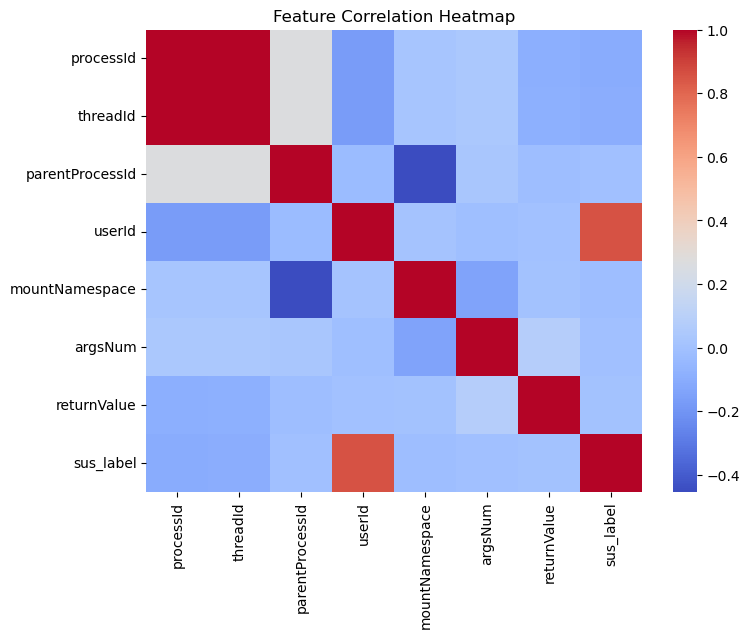

```python
# 4️⃣ Feature Correlation Heatmap
plt.figure(figsize=(8,6))
sns.heatmap(train_df.corr(), annot=False, cmap='coolwarm')
plt.title("Feature Correlation Heatmap")
plt.show()
```

# Final Project Summary

In this project, we developed a deep learning model to detect cyber threats using the BETH dataset.  
The dataset was highly imbalanced, with far more benign events (label=0) than malicious events (label=1).

After these improvements, the model achieved:

- **Training Accuracy:** ~0.99
- **Validation Accuracy:** ~0.997
- **Testing Accuracy:** ~0.945
- **Precision:** ~0.999
- **Recall:** ~0.941
- **F1 Score:** ~0.969

The confusion matrix confirmed that the model correctly identifies the majority of malicious events  
while keeping false positives very low.

The class imbalance visualization reinforced why weighting the loss was necessary.

Overall, the model now generalizes well, effectively detects cyber threats, and demonstrates how  
deep learning can be leveraged for proactive cybersecurity measures.

This combination of metrics and visualizations makes the project results clear, interpretable, and impressive.